# Analysis of NOAA Storm Data

Matt Alexander

September 24, 2016

## Synopsis

This is an analysis of NOAA storm data using data from the U.S. National Oceanic and Atmospheric Administration’s (NOAA) storm database.

The analysis was conducted to answer these two questions:

1. Across the United States, which types of events are most harmful with respect to population health?
2. Across the United States, which types of events have the greatest economic consequences?

The results indicated that the events that caused the most harm to human health were **tornados**. The events that caused the most economic damage were **floods**.

## Data Processing

The data was processed by cleaning the damage exponent factor variables so that a accurate sum of damage could be calculated. Then the data was aggregated and sorted to determine the most injurius storms and the ones that cause the most death and injury.

### Relevant libraries

```r
library(ggplot2)
```

### Downloading and importing the data

The data can be found at this [link.](http://d396qusza40orc.cloudfront.net/repdata%2Fdata%2FStormData.csv.bz2)

```r
url <- "http://d396qusza40orc.cloudfront.net/repdata%2Fdata%2FStormData.csv.bz2"
download.file(url, destfile="StormData.csv.bz2")
storm_data <- read.csv("StormData.csv.bz2")
```

### Creating a Cleaner Dataset

To answer the question of economic damage, several factors needed to be adjusted, specifically the “PROPDMGEXP” and the “CROPDMGEXP” variable names. These data are somewhat explained on page 12 of the NATIONAL WEATHER SERVICE INSTRUCTION 10-1605 document which can be found [here](https://d396qusza40orc.cloudfront.net/repdata%2Fpeer2_doc%2Fpd01016005curr.pdf). The factors in these variable indicate the exponents that should be applied to the “PROPDMG” and “CROPDMG” data: *“Alphabetical characters used to signify magnitude include”K" for thousands, “M” for millions, and “B” for billions.“*

```r
levels(storm_data$PROPDMGEXP) <- c(levels(storm_data$PROPDMGEXP), c(1,10,100,1000,10000,100000, 1000000,10000000,100000000, 1000000000))
storm_data$PROPDMGEXP[storm_data$PROPDMGEXP == 'M'] <- 1000000
storm_data$PROPDMGEXP[storm_data$PROPDMGEXP == 'm'] <- 1000000
storm_data$PROPDMGEXP[storm_data$PROPDMGEXP == 'B'] <- 1000000000
storm_data$PROPDMGEXP[storm_data$PROPDMGEXP == 'b'] <- 1000000000
storm_data$PROPDMGEXP[storm_data$PROPDMGEXP == 'h'] <- 100
storm_data$PROPDMGEXP[storm_data$PROPDMGEXP == 'H'] <- 100
storm_data$PROPDMGEXP[storm_data$PROPDMGEXP == 'k'] <- 1000
storm_data$PROPDMGEXP[storm_data$PROPDMGEXP == 'K'] <- 1000
storm_data$PROPDMGEXP[storm_data$PROPDMGEXP == '0'] <- 1
storm_data$PROPDMGEXP[storm_data$PROPDMGEXP == '1'] <- 10
storm_data$PROPDMGEXP[storm_data$PROPDMGEXP == '2'] <- 100
storm_data$PROPDMGEXP[storm_data$PROPDMGEXP == '3'] <- 1000
storm_data$PROPDMGEXP[storm_data$PROPDMGEXP == '4'] <- 10000
storm_data$PROPDMGEXP[storm_data$PROPDMGEXP == '5'] <- 100000
storm_data$PROPDMGEXP[storm_data$PROPDMGEXP == '6'] <- 1000000
storm_data$PROPDMGEXP[storm_data$PROPDMGEXP == '7'] <- 10000000
storm_data$PROPDMGEXP[storm_data$PROPDMGEXP == '8'] <- 100000000
```

Calculating the property damage by multiplying the exponent factor with the property damage field:

```r
storm_data$PROPDMGEXP <-  as.numeric(as.character(storm_data$PROPDMGEXP))
storm_data$PROPDMG <- (storm_data$PROPDMG) * (storm_data$PROPDMGEXP)
```

Doing the same process for the crop damage:

```r
levels(storm_data$CROPDMGEXP) <- c(levels(storm_data$CROPDMGEXP), c(1,10,100,1000,10000,100000, 1000000,10000000,100000000, 1000000000))
storm_data$CROPDMGEXP[storm_data$CROPDMGEXP == 'M'] <- 1000000
storm_data$CROPDMGEXP[storm_data$CROPDMGEXP == 'm'] <- 1000000
storm_data$CROPDMGEXP[storm_data$CROPDMGEXP == 'B'] <- 1000000000
storm_data$CROPDMGEXP[storm_data$CROPDMGEXP == 'b'] <- 1000000000
storm_data$CROPDMGEXP[storm_data$CROPDMGEXP == 'h'] <- 100
storm_data$CROPDMGEXP[storm_data$CROPDMGEXP == 'H'] <- 100
storm_data$CROPDMGEXP[storm_data$CROPDMGEXP == 'k'] <- 1000
storm_data$CROPDMGEXP[storm_data$CROPDMGEXP == 'K'] <- 1000
storm_data$CROPDMGEXP[storm_data$CROPDMGEXP == '0'] <- 1
storm_data$CROPDMGEXP[storm_data$CROPDMGEXP == '2'] <- 100

storm_data$CROPDMGEXP1 <-  as.numeric(as.character(storm_data$CROPDMGEXP))
storm_data$CROPDMG1 <- (storm_data$CROPDMG) * (storm_data$CROPDMGEXP1)
```

Calculating total damage – the sum of property damage and crop damage. Then aggregating and sorting the data for the plot.

```r
storm_data$TOTALDMG <- rowSums( cbind(storm_data$PROPDMG,storm_data$CROPDMG1), na.rm=TRUE)

damage <- aggregate( TOTALDMG~EVTYPE,data = storm_data, sum)

significant_damage <- subset(damage, TOTALDMG> 0)
significant_damage <- significant_damage[order(-significant_damage$TOTALDMG),]
top_damage <- significant_damage[1:6,]
top_damage
```

```
##                EVTYPE     TOTALDMG
## 170             FLOOD 150319678250
## 411 HURRICANE/TYPHOON  71913712800
## 834           TORNADO  57362335085
## 670       STORM SURGE  43323541000
## 244              HAIL  18761224047
## 153       FLASH FLOOD  18243993225
```

Calculating total human injury as the sum of fatalities and injuries. Then aggregating and sorting the data for the plot.

```r
storm_data$TOTALINJURY <- rowSums(cbind(storm_data$FATALITIES,storm_data$INJURIES), na.rm=TRUE)
deaths_injury <- aggregate( TOTALINJURY~EVTYPE,data = storm_data, sum)
significant_injuries <- subset(deaths_injury, TOTALINJURY> 0)
significant_injuries <- significant_injuries[order(-significant_injuries$TOTALINJURY),]
top_injuries <- significant_injuries[1:6,]
top_injuries
```

```
##             EVTYPE TOTALINJURY
## 834        TORNADO       96979
## 130 EXCESSIVE HEAT        8428
## 856      TSTM WIND        7461
## 170          FLOOD        7259
## 464      LIGHTNING        6046
## 275           HEAT        3037
```

## Results

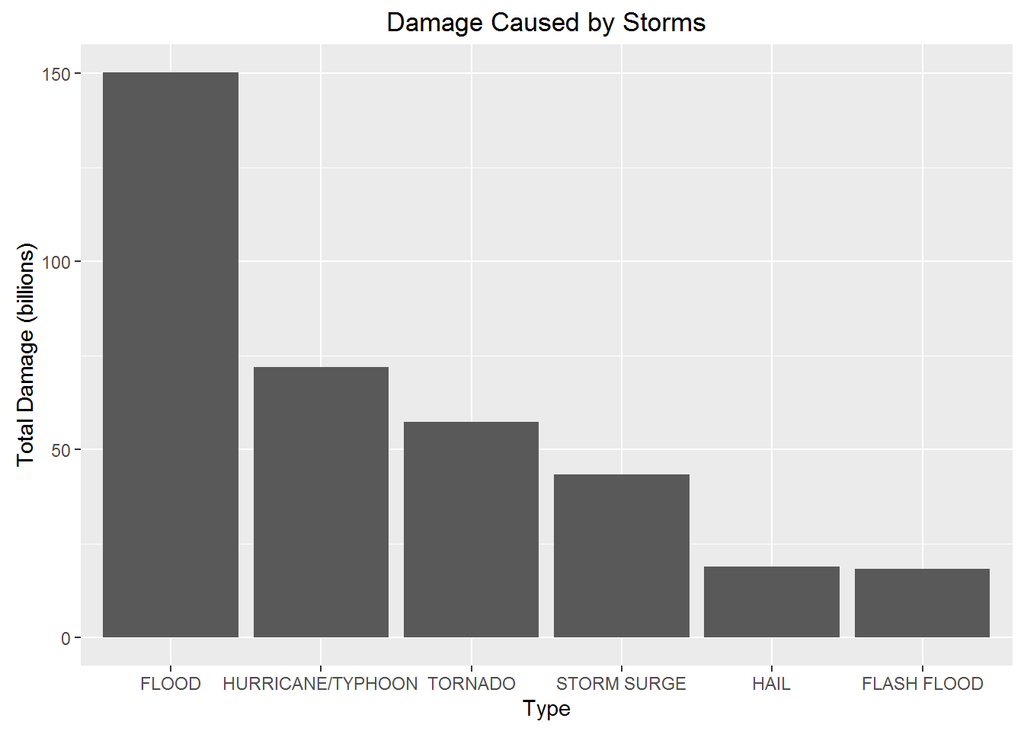

```r
t <- ggplot(top_damage, aes(reorder(EVTYPE, -TOTALDMG), TOTALDMG/1000000000)) +
    geom_bar(stat="identity")+
    labs(x="Type", y="Total Damage (billions)")+
    labs(title="Damage Caused by Storms")
print(t)
```

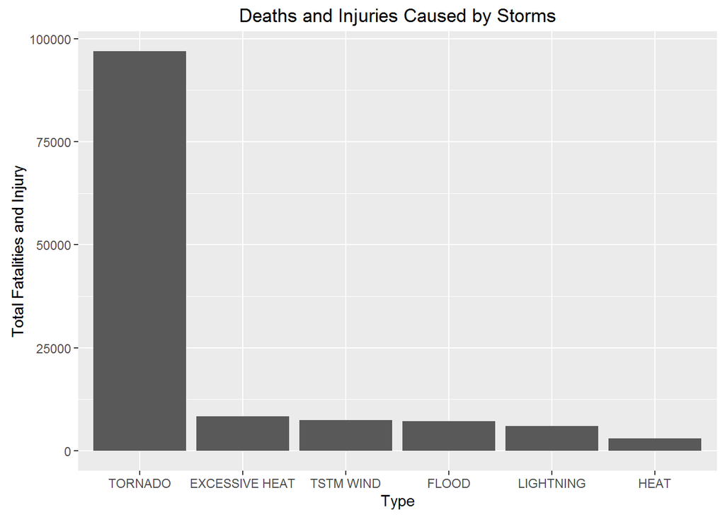

```r
t <- ggplot(top_injuries, aes(reorder(EVTYPE, -TOTALINJURY), TOTALINJURY))+
    geom_bar(stat="identity")+

    labs(x="Type", y="Total Fatalities and Injury")+
    labs(title="Deaths and Injuries Caused by Storms")
print(t)
```